# Latihan 2 - Model Autoregressive Distributed Lag (ARDL) Sales & Advertising

## Input Data

Data diinput langsung sesuai tabel pada soal (40 tahun data Sales dan Advertising, 1975-2014).

```r
data <- data.frame(
  Year = 1975:2014,
  Sales = c(11.7, 12.0, 12.3, 12.8, 13.1, 13.6, 13.9, 14.4, 14.7, 15.3,
            15.5, 15.8, 16.1, 16.6, 16.9, 16.7, 16.9, 17.4, 17.6, 17.9,
            18.0, 17.9, 18.0, 18.2, 18.2, 18.3, 18.6, 19.2, 19.3, 19.5,
            19.2, 19.3, 19.5, 20.0, 20.0, 19.9, 19.8, 19.9, 20.2, 21.0),
  Advertising = c(9.4, 9.6, 10.0, 10.4, 10.8, 10.9, 11.7, 12.2, 12.5, 12.9,
                  13.0, 13.2, 13.8, 14.2, 14.6, 14.4, 15.0, 15.4, 15.7, 15.9,
                  15.9, 16.0, 16.3, 16.2, 16.8, 17.3, 17.6, 18.1, 18.3, 18.5,
                  18.7, 18.9, 19.2, 20.0, 20.0, 20.3, 20.4, 21.0, 21.5, 22.1)
)
str(data)
```

```
## 'data.frame':    40 obs. of  3 variables:
##  $ Year       : int  1975 1976 1977 1978 1979 1980 1981 1982 1983 1984 ...
##  $ Sales      : num  11.7 12 12.3 12.8 13.1 13.6 13.9 14.4 14.7 15.3 ...
##  $ Advertising: num  9.4 9.6 10 10.4 10.8 10.9 11.7 12.2 12.5 12.9 ...
```

```r
data
```

```
##    Year Sales Advertising
## 1  1975  11.7         9.4
## 2  1976  12.0         9.6
## 3  1977  12.3        10.0
## 4  1978  12.8        10.4
## 5  1979  13.1        10.8
## 6  1980  13.6        10.9
## 7  1981  13.9        11.7
## 8  1982  14.4        12.2
## 9  1983  14.7        12.5
## 10 1984  15.3        12.9
## 11 1985  15.5        13.0
## 12 1986  15.8        13.2
## 13 1987  16.1        13.8
## 14 1988  16.6        14.2
```

[output cut: 26 more lines]

## Pembagian Data

```r
#SPLIT DATA
train<-data[1:30,]
test<-data[31:40,]
```

```r
#data time series
train.ts<-ts(train)
test.ts<-ts(test)
data.ts<-ts(data)
```

Sesuai instruksi soal, dilakukan pemodelan **Autoregressive Distributed Lag (ARDL)** dari peubah Sales (Y) terhadap Advertising (X), lalu dicari model terbaik.

## Model Autoregressive (ARDL)

Peubah dependen dipengaruhi oleh peubah independen pada waktu sekarang, serta dipengaruhi juga oleh peubah dependen itu sendiri pada satu waktu yang lalu maka model tersebut disebut *autoregressive* (Gujarati 2004).

### Pemodelan Awal

Pemodelan Autoregressive dilakukan menggunakan fungsi `dLagM::ardlDlm()` . Fungsi tersebut akan menerapkan *autoregressive* berordo $(p,q)$ dengan satu prediktor. Fungsi umum dari `ardlDlm()` adalah sebagai berikut.

```r
ardlDlm(formula = NULL , data = NULL , x = NULL , y = NULL , p = 1 , q = 1 ,
         remove = NULL )
```

Dengan $p$ adalah integer yang mewakili panjang *lag* yang terbatas dan $q$ adalah integer yang merepresentasikan ordo dari proses *autoregressive*.

```r
model.ardl <- ardlDlm(x = train$Advertising, y = train$Sales, p = 1 , q = 1)
summary(model.ardl)
```

```
##
## Time series regression with "ts" data:
## Start = 2, End = 30
##
## Call:
## dynlm(formula = as.formula(model.text), data = data, start = 1)
##
## Residuals:
##       Min        1Q    Median        3Q       Max
## -0.229277 -0.127437  0.009143  0.109228  0.259132
##
## Coefficients:
##             Estimate Std. Error t value Pr(>|t|)
## (Intercept)  1.55786    0.44353   3.512  0.00171 **
## X.t          0.29110    0.13707   2.124  0.04376 *
## X.1         -0.09584    0.16067  -0.596  0.55621
## Y.1          0.74360    0.09964   7.463 8.14e-08 ***
## ---
## Signif. codes:  0 '***' 0.001 '**' 0.01 '*' 0.05 '.' 0.1 ' ' 1
##
## Residual standard error: 0.1576 on 25 degrees of freedom
## Multiple R-squared:  0.9955, Adjusted R-squared:  0.9949
## F-statistic:  1830 on 3 and 25 DF,  p-value: < 2.2e-16
```

```r
AIC(model.ardl)
```

```
## [1] -19.18177
```

```r
BIC(model.ardl)
```

```
## [1] -12.34529
```

```r
model.ardl <- ardlDlm(formula = Sales ~ Advertising,
                         data = train, p = 1 , q = 1)
summary(model.ardl)
```

```
##
## Time series regression with "ts" data:
## Start = 2, End = 30
##
## Call:
## dynlm(formula = as.formula(model.text), data = data)
##
## Residuals:
##       Min        1Q    Median        3Q       Max
## -0.229277 -0.127437  0.009143  0.109228  0.259132
##
## Coefficients:
##               Estimate Std. Error t value Pr(>|t|)
## (Intercept)    1.55786    0.44353   3.512  0.00171 **
## Advertising.t  0.29110    0.13707   2.124  0.04376 *
## Advertising.1 -0.09584    0.16067  -0.596  0.55621
## Sales.1        0.74360    0.09964   7.463 8.14e-08 ***
## ---
## Signif. codes:  0 '***' 0.001 '**' 0.01 '*' 0.05 '.' 0.1 ' ' 1
##
## Residual standard error: 0.1576 on 25 degrees of freedom
## Multiple R-squared:  0.9955, Adjusted R-squared:  0.9949
## F-statistic:  1830 on 3 and 25 DF,  p-value: < 2.2e-16
```

```r
AIC(model.ardl)
```

```
## [1] -19.18177
```

```r
BIC(model.ardl)
```

```
## [1] -12.34529
```

### Peramalan dan Akurasi (p=1, q=1)

```r
fore.ardl <- forecast(model = model.ardl, x=test$Advertising, h=10)
fore.ardl
```

```
## $forecasts
##  [1] 19.72862 19.93768 20.16129 20.53170 20.73047 20.96560 21.14081 21.43616
##  [9] 21.74384 22.09937
##
## $call
## forecast.ardlDlm(model = model.ardl, x = test$Advertising, h = 10)
##
## attr(,"class")
## [1] "forecast.ardlDlm" "dLagM"
```

```r
mape.ardl <- MAPE(fore.ardl$forecasts, test$Sales)
mape.ardl
```

```
## [1] 0.0484832
```

```r
#akurasi data training
GoF(model.ardl)
```

```
##             n       MAE           MPE        MAPE       sMAPE      MASE
## model.ardl 29 0.1238592 -0.0001484019 0.007696613 0.007697173 0.4281553
##                  MSE     MRAE     GMRAE
## model.ardl 0.0214047 81884782 0.7548444
```

### *Lag* Optimum

Selanjutnya dicari kombinasi $p$ (lag X) dan $q$ (lag Y) yang optimum menggunakan `ardlBoundOrders()`.

```r
#penentuan lag optimum
model.ardl.opt <- ardlBoundOrders(data = data.frame(data), ic = "AIC",
                                  formula = Sales ~ Advertising )
model.ardl.opt
```

```
## $p
##   Advertising
## 1           4
##
## $q
## [1] 15
##
## $Stat.table
##             q = 1      q = 2      q = 3       q = 4        q = 5      q = 6
## p = 1  -15.008746 -11.952031 -11.702811 -10.4556102   -7.4743459 -10.190508
## p = 2  -13.773954 -12.129560 -11.273832  -9.7873186   -6.6233481  -8.740430
## p = 3   -8.848612  -8.848612 -12.443867 -10.3937201   -7.1398397  -9.693082
## p = 4  -12.022451 -10.663941 -10.663941  -8.6692457   -5.3883982  -8.000189
## p = 5   -6.455663  -4.517684  -6.129877  -6.1298773   -5.8218760  -9.506366
## p = 6  -11.513095  -9.679368 -10.603965  -8.7469140   -8.7469140  -8.630625
## p = 7   -5.508868  -3.728014  -6.010216  -4.5325635  -12.0788009 -12.078801
## p = 8   -8.927789  -7.599283  -5.788882  -4.6394213  -11.9646171 -10.910332
## p = 9   -5.602665  -3.769155  -2.219895  -0.2595925   -9.1716507  -7.295497
## p = 10  -9.465550  -7.587108  -5.720971  -3.8196288   -8.1361157  -6.288259
## p = 11   1.701332   2.523049   3.963660   5.8214473   -0.1570961   1.564017
## p = 12  -6.976292  -6.760264  -4.921983  -7.0600636   -9.0408197  -8.605279
## p = 13  -1.534882  -4.200569  -6.944121  -5.0254590  -32.2884029 -46.908793
## p = 14  -3.660390  -1.761109  -2.219038  -3.7538496 -198.9302277         NA
## p = 15 -11.707853 -17.884028 -17.585602          NA           NA         NA
##             q = 7      q = 8        q = 9      q = 10       q = 11     q = 12
## p = 1   -7.624070  -8.686449   -4.7462387 -3.32746110   -2.9869318 -0.9555962
## p = 2   -5.806960  -7.921509   -4.2989938 -2.59233785   -1.1348530  0.3798720
## p = 3   -6.091044  -7.142078   -4.2143900 -1.64141900   -0.2764654  2.0637751
## p = 4   -4.274001  -5.164970   -2.2163924 -0.02517076    0.1775901  3.0432639
## p = 5   -5.454353  -5.301255   -1.9990132  0.94455082    1.2370098  2.5673773
## p = 6   -4.511772  -3.986967   -0.7254173  2.14054832    2.0257425  0.1204914
## p = 7  -13.506180 -11.580354   -7.7220728 -3.84200566   -3.0518769 -4.1223494
## p = 8  -10.910332  -9.645933   -5.8154895 -2.15509138   -2.0247232 -3.0170743
## p = 9   -6.993088  -6.993088   -5.9083235 -2.05781567   -0.3245455 -1.0178440
## p = 10  -7.323609  -8.441982   -8.4419817 -8.92421877   -7.3319735 -5.7824865
## p = 11  -1.509374  -6.042816   -9.7853072 -9.78530724 -121.6529036         NA
## p = 12  -6.819227 -19.795453 -125.1056421          NA           NA         NA
## p = 13 -93.617891         NA           NA          NA           NA         NA
## p = 14         NA         NA           NA          NA           NA         NA
## p = 15         NA         NA           NA          NA           NA         NA
##            q = 13     q = 14     q = 15
## p = 1    2.983211   2.566813  -17.54638
## p = 2    3.581183   4.065066  -76.93283
## p = 3    5.505343   5.691237  -97.73207
## p = 4    6.600634   6.567285 -305.75496
## p = 5    5.541829  -6.747419         NA
## p = 6   -4.715695 -94.241328         NA
## p = 7  -42.546289         NA         NA
## p = 8  -47.628148         NA         NA
## p = 9          NA         NA         NA
## p = 10         NA         NA         NA
## p = 11         NA         NA         NA
## p = 12         NA         NA         NA
## p = 13         NA         NA         NA
## p = 14         NA         NA         NA
## p = 15         NA         NA         NA
##
## $min.Stat
## [1] -305.755
```

```r
min_p=c()
for(i in 1:6){
  min_p[i]=min(model.ardl.opt$Stat.table[[i]])
}
q_opt=which(min_p==min(min_p, na.rm = TRUE))
p_opt=which(model.ardl.opt$Stat.table[[q_opt]] ==
              min(model.ardl.opt$Stat.table[[q_opt]], na.rm = TRUE))
data.frame("q_optimum" = q_opt, "p_optimum" = p_opt,
           "AIC"=model.ardl.opt$min.Stat)
```

```
##   q_optimum p_optimum      AIC
## 1         2        15 -305.755
```

```r
#ganti p dan q di bawah sesuai hasil p_opt & q_opt di atas
model.ardl.opt2 <- ardlDlm(formula = Sales ~ Advertising,
                         data = train, p = 1 , q = 1)
summary(model.ardl.opt2)
```

```
##
## Time series regression with "ts" data:
## Start = 2, End = 30
##
## Call:
## dynlm(formula = as.formula(model.text), data = data)
##
## Residuals:
##       Min        1Q    Median        3Q       Max
## -0.229277 -0.127437  0.009143  0.109228  0.259132
##
## Coefficients:
##               Estimate Std. Error t value Pr(>|t|)
## (Intercept)    1.55786    0.44353   3.512  0.00171 **
## Advertising.t  0.29110    0.13707   2.124  0.04376 *
## Advertising.1 -0.09584    0.16067  -0.596  0.55621
## Sales.1        0.74360    0.09964   7.463 8.14e-08 ***
## ---
## Signif. codes:  0 '***' 0.001 '**' 0.01 '*' 0.05 '.' 0.1 ' ' 1
##
## Residual standard error: 0.1576 on 25 degrees of freedom
## Multiple R-squared:  0.9955, Adjusted R-squared:  0.9949
## F-statistic:  1830 on 3 and 25 DF,  p-value: < 2.2e-16
```

```r
AIC(model.ardl.opt2)
```

```
## [1] -19.18177
```

```r
BIC(model.ardl.opt2)
```

```
## [1] -12.34529
```

```r
fore.ardl.opt <- forecast(model = model.ardl.opt2, x=test$Advertising, h=10)
fore.ardl.opt
```

```
## $forecasts
##  [1] 19.72862 19.93768 20.16129 20.53170 20.73047 20.96560 21.14081 21.43616
##  [9] 21.74384 22.09937
##
## $call
## forecast.ardlDlm(model = model.ardl.opt2, x = test$Advertising,
##     h = 10)
##
## attr(,"class")
## [1] "forecast.ardlDlm" "dLagM"
```

```r
mape.ardl.opt <- MAPE(fore.ardl.opt$forecasts, test$Sales)
mape.ardl.opt
```

```
## [1] 0.0484832
```

```r
#akurasi data training
GoF(model.ardl.opt2)
```

```
##                  n       MAE           MPE        MAPE       sMAPE      MASE
## model.ardl.opt2 29 0.1238592 -0.0001484019 0.007696613 0.007697173 0.4281553
##                       MSE     MRAE     GMRAE
## model.ardl.opt2 0.0214047 81884782 0.7548444
```

## Pemodelan ARDL dengan Library `dynlm`

Pemodelan ARDL juga dapat dibandingkan menggunakan *packages* `dynlm` untuk melihat ringkasan model dan melakukan uji asumsi.

`encomptest()` mensyaratkan kedua model yang dibandingkan memiliki **jumlah observasi yang sama** setelah proses lag. Karena itu, model yang dibandingkan lewat `encomptest()` harus punya *lag maksimum* yang sama (di sini sama-sama lag 1), supaya jumlah baris yang hilang akibat lag identik.

```r
#sama dengan model dlm q=1 (lag maks = 1)
cons_lm1 <- dynlm(Sales ~ Advertising+L(Advertising),data = train.ts)

#sama dengan model ardl p=1 q=0 (lag maks = 1)
cons_lm2 <- dynlm(Sales ~ Advertising+L(Sales),data = train.ts)

#sama dengan ardl p=1 q=1 (lag maks = 1)
cons_lm3 <- dynlm(Sales ~ Advertising+L(Advertising)+L(Sales),data = train.ts)

#sama dengan dlm q=2 (lag maks = 2, tidak dibandingkan lewat encomptest karena beda lag maks)
cons_lm4 <- dynlm(Sales ~ Advertising+L(Advertising)+L(Advertising,2),data = train.ts)
```

### Ringkasan Model

```r
summary(cons_lm1)
```

```
##
## Time series regression with "ts" data:
## Start = 2, End = 30
##
## Call:
## dynlm(formula = Sales ~ Advertising + L(Advertising), data = train.ts)
##
## Residuals:
##      Min       1Q   Median       3Q      Max
## -0.45641 -0.21066  0.03391  0.20084  0.43319
##
## Coefficients:
##                Estimate Std. Error t value Pr(>|t|)
## (Intercept)      4.5932     0.3117  14.738 3.89e-14 ***
## Advertising      0.2796     0.2415   1.158    0.257
## L(Advertising)   0.5510     0.2383   2.312    0.029 *
## ---
## Signif. codes:  0 '***' 0.001 '**' 0.01 '*' 0.05 '.' 0.1 ' ' 1
##
## Residual standard error: 0.2776 on 26 degrees of freedom
## Multiple R-squared:  0.9854, Adjusted R-squared:  0.9842
## F-statistic: 875.4 on 2 and 26 DF,  p-value: < 2.2e-16
```

```r
summary(cons_lm2)
```

```
##
## Time series regression with "ts" data:
## Start = 2, End = 30
##
## Call:
## dynlm(formula = Sales ~ Advertising + L(Sales), data = train.ts)
##
## Residuals:
##       Min        1Q    Median        3Q       Max
## -0.241256 -0.124752  0.008004  0.121297  0.272373
##
## Coefficients:
##             Estimate Std. Error t value Pr(>|t|)
## (Intercept)  1.71947    0.34678   4.958 3.75e-05 ***
## Advertising  0.22200    0.07235   3.068  0.00498 **
## L(Sales)     0.71154    0.08285   8.588 4.56e-09 ***
## ---
## Signif. codes:  0 '***' 0.001 '**' 0.01 '*' 0.05 '.' 0.1 ' ' 1
##
## Residual standard error: 0.1556 on 26 degrees of freedom
## Multiple R-squared:  0.9954, Adjusted R-squared:  0.995
## F-statistic:  2814 on 2 and 26 DF,  p-value: < 2.2e-16
```

```r
summary(cons_lm3)
```

```
##
## Time series regression with "ts" data:
## Start = 2, End = 30
##
## Call:
## dynlm(formula = Sales ~ Advertising + L(Advertising) + L(Sales),
##     data = train.ts)
##
## Residuals:
##       Min        1Q    Median        3Q       Max
## -0.229277 -0.127437  0.009143  0.109228  0.259132
##
## Coefficients:
##                Estimate Std. Error t value Pr(>|t|)
## (Intercept)     1.55786    0.44353   3.512  0.00171 **
## Advertising     0.29110    0.13707   2.124  0.04376 *
## L(Advertising) -0.09584    0.16067  -0.596  0.55621
## L(Sales)        0.74360    0.09964   7.463 8.14e-08 ***
## ---
## Signif. codes:  0 '***' 0.001 '**' 0.01 '*' 0.05 '.' 0.1 ' ' 1
##
## Residual standard error: 0.1576 on 25 degrees of freedom
## Multiple R-squared:  0.9955, Adjusted R-squared:  0.9949
## F-statistic:  1830 on 3 and 25 DF,  p-value: < 2.2e-16
```

```r
summary(cons_lm4)
```

```
##
## Time series regression with "ts" data:
## Start = 3, End = 30
##
## Call:
## dynlm(formula = Sales ~ Advertising + L(Advertising) + L(Advertising,
##     2), data = train.ts)
##
## Residuals:
##      Min       1Q   Median       3Q      Max
## -0.49181 -0.15731 -0.00976  0.15782  0.48554
##
## Coefficients:
##                   Estimate Std. Error t value Pr(>|t|)
## (Intercept)         4.9621     0.3453  14.369 2.76e-13 ***
## Advertising         0.1654     0.2362   0.700    0.490
## L(Advertising)      0.4118     0.3036   1.356    0.188
## L(Advertising, 2)   0.2365     0.2299   1.028    0.314
## ---
## Signif. codes:  0 '***' 0.001 '**' 0.01 '*' 0.05 '.' 0.1 ' ' 1
##
## Residual standard error: 0.2644 on 24 degrees of freedom
## Multiple R-squared:  0.9857, Adjusted R-squared:  0.9839
## F-statistic: 550.5 on 3 and 24 DF,  p-value: < 2.2e-16
```

### SSE

```r
deviance(cons_lm1)
```

```
## [1] 2.003617
```

```r
deviance(cons_lm2)
```

```
## [1] 0.6295707
```

```r
deviance(cons_lm3)
```

```
## [1] 0.6207363
```

```r
deviance(cons_lm4)
```

```
## [1] 1.677992
```

Semakin kecil nilai SSE, berarti model lebih baik dalam menyesuaikan data (karena error lebih kecil).

### Uji Encomptest

`cons_lm1` dan `cons_lm2` sama-sama punya lag maksimum 1 (jumlah observasi setelah lag sama), sehingga bisa dibandingkan dengan `encomptest()` untuk melihat apakah penambahan lag Y (`L(Sales)`) atau lag X (`L(Advertising)`) memberikan peningkatan signifikan.

```r
#uji model
if(require("lmtest")) encomptest(cons_lm1, cons_lm2)
```

```
## Encompassing test
##
## Model 1: Sales ~ Advertising + L(Advertising)
## Model 2: Sales ~ Advertising + L(Sales)
## Model E: Sales ~ Advertising + L(Advertising) + L(Sales)
##           Res.Df Df       F    Pr(>F)
## M1 vs. ME     25 -1 55.6952 8.144e-08 ***
## M2 vs. ME     25 -1  0.3558    0.5562
## ---
## Signif. codes:  0 '***' 0.001 '**' 0.01 '*' 0.05 '.' 0.1 ' ' 1
```

#### Uji Autokorelasi Residual

```r
#durbin watson
dwtest(cons_lm1)
```

```
##
##  Durbin-Watson test
##
## data:  cons_lm1
## DW = 0.37269, p-value = 1.393e-09
## alternative hypothesis: true autocorrelation is greater than 0
```

```r
dwtest(cons_lm2)
```

```
##
##  Durbin-Watson test
##
## data:  cons_lm2
## DW = 1.8706, p-value = 0.2357
## alternative hypothesis: true autocorrelation is greater than 0
```

```r
dwtest(cons_lm3)
```

```
##
##  Durbin-Watson test
##
## data:  cons_lm3
## DW = 1.9917, p-value = 0.3507
## alternative hypothesis: true autocorrelation is greater than 0
```

```r
dwtest(cons_lm4)
```

```
##
##  Durbin-Watson test
##
## data:  cons_lm4
## DW = 0.45322, p-value = 5.492e-08
## alternative hypothesis: true autocorrelation is greater than 0
```

#### Uji Heterogenitas

```r
bptest(cons_lm1)
```

```
##
##  studentized Breusch-Pagan test
##
## data:  cons_lm1
## BP = 0.29867, df = 2, p-value = 0.8613
```

```r
bptest(cons_lm2)
```

```
##
##  studentized Breusch-Pagan test
##
## data:  cons_lm2
## BP = 0.12148, df = 2, p-value = 0.9411
```

```r
bptest(cons_lm3)
```

```
##
##  studentized Breusch-Pagan test
##
## data:  cons_lm3
## BP = 0.66214, df = 3, p-value = 0.8821
```

```r
bptest(cons_lm4)
```

```
##
##  studentized Breusch-Pagan test
##
## data:  cons_lm4
## BP = 3.1875, df = 3, p-value = 0.3636
```

- Jika p-value > 0.05 → tidak ada heteroskedastisitas
- Jika p-value ≤ 0.05 → ada heteroskedastisitas.

#### Uji Normalitas

H0: Residual berdistribusi normal.

H1: Residual tidak berdistribusi normal.

```r
shapiro.test(residuals(cons_lm1))
```

```
##
##  Shapiro-Wilk normality test
##
## data:  residuals(cons_lm1)
## W = 0.94714, p-value = 0.1542
```

```r
shapiro.test(residuals(cons_lm2))
```

```
##
##  Shapiro-Wilk normality test
##
## data:  residuals(cons_lm2)
## W = 0.95861, p-value = 0.3036
```

```r
shapiro.test(residuals(cons_lm3))
```

```
##
##  Shapiro-Wilk normality test
##
## data:  residuals(cons_lm3)
## W = 0.95502, p-value = 0.2466
```

```r
shapiro.test(residuals(cons_lm4))
```

```
##
##  Shapiro-Wilk normality test
##
## data:  residuals(cons_lm4)
## W = 0.98152, p-value = 0.8851
```

- Jika p-value > 0.05 → gagal tolak H0 → residual normal.
- Jika p-value ≤ 0.05 → tolak H0 → residual tidak normal.

## Perbandingan Model

```r
akurasi <- matrix(c(mape.ardl, mape.ardl.opt))
row.names(akurasi)<- c("ARDL (p=1,q=1)","ARDL (lag optimum)")
colnames(akurasi) <- c("MAPE")
akurasi
```

```
##                         MAPE
## ARDL (p=1,q=1)     0.0484832
## ARDL (lag optimum) 0.0484832
```

Model dengan nilai MAPE terkecil merupakan model ARDL terbaik untuk memprediksi Sales berdasarkan Advertising.

### Plot

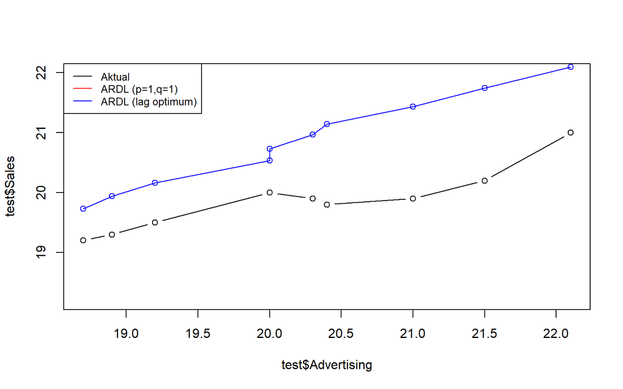

```r
par(mfrow=c(1,1))  # atur layout grafik tunggal

# plot data aktual
plot(test$Advertising, test$Sales, type="b", col="black",
     ylim=c(min(test$Sales)-1, max(test$Sales)+1))

# tambahkan garis ramalan dari masing-masing model
points(test$Advertising, fore.ardl$forecasts, col="red");     lines(test$Advertising, fore.ardl$forecasts, col="red")
points(test$Advertising, fore.ardl.opt$forecasts, col="blue"); lines(test$Advertising, fore.ardl.opt$forecasts, col="blue")

# legenda model
legend("topleft",
       c("Aktual", "ARDL (p=1,q=1)","ARDL (lag optimum)"),
       lty=1, col=c("black","red","blue"), cex=0.8)
```